# Multiple and Generalized Nonparametric Regression in R

[Nathaniel E. Helwig](http://stat.umn.edu/~helwig) Department of Psychology & School of Statistics University of Minnesota

Copyright © April 21, 2026

# 1 Introduction

## 1.1 Motivation and Goals

Multiple and generalized nonparametric regression models are powerful extensions of generalized linear models that can be used to estimate unknown functional relationships between a collection of predictors $X_1,\ldots,X_p$ and an exponential family response variable $Y$. In R, several options exist for fitting such models. This document focuses on the `gam` function (in the **mgcv** package) and the `gsm` function (in the **npreg** package), both of which use a regression spline approach for the function estimation. This document provides theoretical background on multiple and generalized nonparametric regression models, as well as examples that illustrate how to use the `gam` and `gsm` functions.

## 1.3 gsm Function (npreg Package)

Syntax:

`gsm(formula, family = gaussian, data, weights, types = NULL, tprk = TRUE,`  
`knots = NULL, update = TRUE, spar = NULL, lambda = NULL, control = list(),`  
`method = c("GCV", "OCV", "GACV", "ACV", "PQL", "AIC", "BIC"))`

Or you could use the `sm` function for Gaussian data:

`sm(formula, data, weights, types = NULL, tprk = TRUE, knots = NULL,`  
`update = TRUE, df, spar = NULL, lambda = NULL, control = list(),`  
`method = c("GCV", "OCV", "GACV", "ACV", "REML", "ML", "AIC", "BIC"))`  
The `sm` function has the benefit of more tuning methods and more efficient computational algorithms.

## 1.4 Comparison of Approaches

### 1.4.1 Overview

The `gam` and `gsm` functions differ in a variety of ways. Some key differences include:

1. The `formula` specification. The `gam` function uses specialized syntax, whereas the `gsm` function uses the standard `formula` syntax, e.g., as used in the `lm` and `glm` functions.
2. The `types` specification. The `gam` function requires the user to specify the smoother type within the `formula` specification via the arguments to the `s` function. The `gsm` function allows the user the input the smoother types separately via the `types` argument. Otherwise, the `gsm` function will infer the smoother type from the variable’s `class`, e.g., numeric class $\leftrightarrow$ cubic spline, factor class $\leftrightarrow$ nominal spline, and ordered class $\leftrightarrow$ ordinal spline.
3. The `knots` specification. The `gam` function requires the user to specify the knots within the `formula` specification via the arguments to the `s` function. The `gsm` function allows the user the input the knots separately via the `knots` argument. Otherwise, the `gsm` function will use a random sample of knots.
4. The `gam` function has more options avaiable for response variables, whereas the `gsm` function has more options avaiable for smoothing parameter selection.
5. Both functions offer some similar smoothers (e.g., cubic smoothing splines), as well as some unique smoothers, e.g., soap film smoothers in the `gam` function or ordinal smoothers in the `gsm` function.

### 1.4.2 Example Function

To see how these functions perform in practice, let’s look at a simulated example. Specifically, let’s simulate some data with a functional relationship where there are two predictors: $X \in [0,1]$ is continuous and $Z \in \{a, b, c\}$ is nominal with 3 levels.

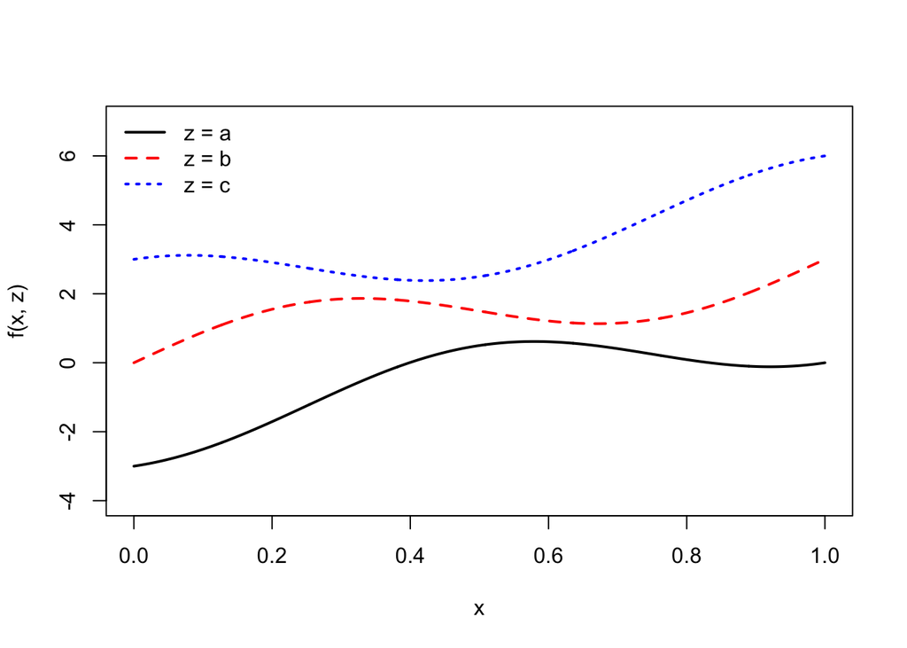

```r
# generate data
set.seed(0)
n <- 1000
x <- seq(0, 1, length.out = n)
z <- factor(sample(letters[1:3], size = n, replace = TRUE), levels = letters[1:3])

# define function
fun <- function(x, z){
  mu <- c(-2, 0, 2)
  zi <- as.integer(z)
  fx <- mu[zi] + 3 * x + sin(2 * pi * x + mu[zi]*pi/4)
}
fx <- fun(x, z)

# plot function
cols <- c("black", "red", "blue")
plot(x, fun(x, z = 1), t = "l", lwd = 2,
     ylim = c(-4, 7), ylab = "f(x, z)")
lines(x, fun(x, z = 2), lty = 2, col = cols[2], lwd = 2)
lines(x, fun(x, z = 3), lty = 3, col = cols[3], lwd = 2)
legend("topleft", legend = paste0("z = ", letters[1:3]),
       lty = 1:3, col = cols, lwd = 2, bty = "n")
```

### 1.4.3 Gaussian Example

Generate some Gaussian data:

```r
set.seed(1)
y <- fx + rnorm(n)
```

Fit model with `gam` function:

```r
library(mgcv)
mod.gam <- gam(y ~ z + s(x, by = z))
mod.gam
```

```
##
## Family: gaussian
## Link function: identity
##
## Formula:
## y ~ z + s(x, by = z)
##
## Estimated degrees of freedom:
## 3.89 4.66 5.02  total = 16.57
##
## GCV score: 1.089394
```

Fit model with `gsm` function:

```r
library(npreg)
probs <- seq(0, 1, length.out = 9)
knots <- list(x = quantile(x, probs = probs), z = letters[1:3])
mod.gsm <- gsm(y ~ x * z, knots = knots)
mod.gsm
```

```
##
## Call:
## gsm(formula = y ~ x * z, knots = knots)
##
## Smoothing Parameter:  spar = 0.7239238   lambda = 0.01012574
## Equivalent Degrees of Freedom (Df):  15.11121
## Penalized Criterion (deviance):  1056.335
## Generalized Cross-Validation (GCV):  1.088998
```

Compare results:

```r
# rmse between truth and estimate
sqrt(mean((fx - mod.gam$linear.predictors)^2))
```

```
## [1] 0.1211713
```

```r
sqrt(mean((fx - mod.gsm$linear.predictors)^2))
```

```
## [1] 0.1067063
```

Note: in this case, the `gsm` function does a bit better at estimating the unknown true function.

Plot results:

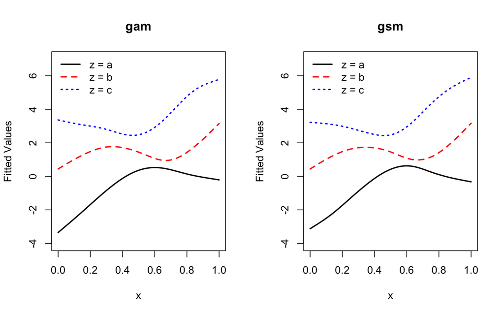

```r
# define new data (for predictions)
xseq <- seq(0, 1, length.out = 100)
newdata <- expand.grid(x = xseq, z = letters[1:3])

# get predictions
yhat.gam <- predict(mod.gam, newdata)
yhat.gsm <- predict(mod.gsm, newdata)

# set-up 1 x 2 subplots
par(mfrow = c(1,2))

# plot predictions (gam)
plot(xseq, yhat.gam[1:100], t = "l", lwd = 2, ylim = c(-4, 7),
     xlab = "x", ylab = "Fitted Values", main = "gam")
lines(xseq, yhat.gam[1:100 + 100], lty = 2, lwd = 2, col = cols[2])
lines(xseq, yhat.gam[1:100 + 200], lty = 3, lwd = 2, col = cols[3])
legend("topleft", legend = paste0("z = ", letters[1:3]),
       lty = 1:3, col = cols, lwd = 2, bty = "n")

# plot predictions (gsm)
plot(xseq, yhat.gsm[1:100], t = "l", lwd = 2, ylim = c(-4, 7),
     xlab = "x", ylab = "Fitted Values", main = "gsm")
lines(xseq, yhat.gsm[1:100 + 100], lty = 2, lwd = 2, col = cols[2])
lines(xseq, yhat.gsm[1:100 + 200], lty = 3, lwd = 2, col = cols[3])
legend("topleft", legend = paste0("z = ", letters[1:3]),
       lty = 1:3, col = cols, lwd = 2, bty = "n")
```

### 1.4.4 Binomial Example

Generate some binomial data:

```r
set.seed(1)
y <- rbinom(n = n, size = 1, p = 1 / (1 + exp(-fx)))
```

Fit model with `gam` function:

```r
library(mgcv)
mod.gam <- gam(y ~ z + s(x, by = z), family = binomial)
mod.gam
```

```
##
## Family: binomial
## Link function: logit
##
## Formula:
## y ~ z + s(x, by = z)
##
## Estimated degrees of freedom:
## 3.06 2.81 2.42  total = 11.29
##
## UBRE score: -0.1454208
```

Fit model with `gsm` function:

```r
library(npreg)
probs <- seq(0, 1, length.out = 9)
knots <- list(x = quantile(x, probs = probs), z = letters[1:3])
mod.gsm <- gsm(y ~ x * z, family = binomial, knots = knots)
mod.gsm
```

```
##
## Call:
## gsm(formula = y ~ x * z, family = binomial, knots = knots)
##
## Smoothing Parameter:  spar = 0.6590861   lambda = 0.003443439
## Equivalent Degrees of Freedom (Df):  10.78028
## Penalized Criterion (deviance):  832.3743
## Generalized Cross-Validation (GCV):  0.4254005
```

Compare results:

```r
# rmse between truth and estimate
sqrt(mean((fx - mod.gam$linear.predictors)^2))
```

```
## [1] 0.6004284
```

```r
sqrt(mean((fx - mod.gsm$linear.predictors)^2))
```

```
## [1] 0.313423
```

Note: in this case, the `gsm` function does noticeably better at estimating the unknown true function.

Plot results:

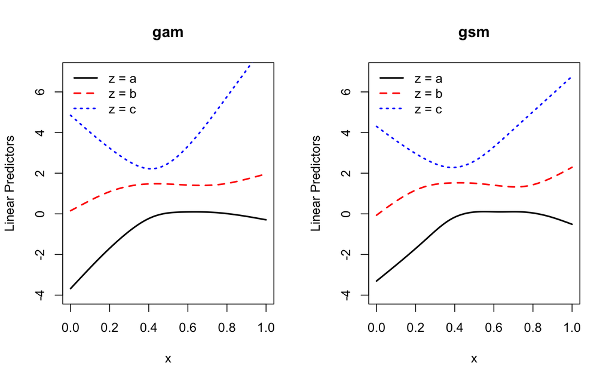

```r
# define new data (for predictions)
xseq <- seq(0, 1, length.out = 100)
newdata <- expand.grid(x = xseq, z = letters[1:3])

# get predictions
yhat.gam <- predict(mod.gam, newdata)
yhat.gsm <- predict(mod.gsm, newdata)

# set-up 1 x 2 subplots
par(mfrow = c(1,2))

# plot predictions (gam)
plot(xseq, yhat.gam[1:100], t = "l", lwd = 2, ylim = c(-4, 7),
     xlab = "x", ylab = "Linear Predictors", main = "gam")
lines(xseq, yhat.gam[1:100 + 100], lty = 2, lwd = 2, col = cols[2])
lines(xseq, yhat.gam[1:100 + 200], lty = 3, lwd = 2, col = cols[3])
legend("topleft", legend = paste0("z = ", letters[1:3]),
       lty = 1:3, col = cols, lwd = 2, bty = "n")

# plot predictions (gsm)
plot(xseq, yhat.gsm[1:100], t = "l", lwd = 2, ylim = c(-4, 7),
     xlab = "x", ylab = "Linear Predictors", main = "gsm")
lines(xseq, yhat.gsm[1:100 + 100], lty = 2, lwd = 2, col = cols[2])
lines(xseq, yhat.gsm[1:100 + 200], lty = 3, lwd = 2, col = cols[3])
legend("topleft", legend = paste0("z = ", letters[1:3]),
       lty = 1:3, col = cols, lwd = 2, bty = "n")
```

# 2 Brief Overview

## 2.1 Model Form

Suppose we an independent sample of $n$ observations $(x_{i1}, \ldots, x_{ip}, y_i) \sim F_{X,Y}$, and assume that $y_i$ follows an exponential family distribution. A multiple and generalized nonparametric regression model assumes that
$$g(\mu_i) = \eta_i = f(x_{i1}, \ldots, x_{ip})$$
where $\mu_i$ is the conditional mean of $y_i$ given $\mathbf{x}_i$, the function $g(\cdot)$ is the known *link* function, the term $\eta_i$ is referred to as the *linear predictor*, and $f(\cdot)$ is the unknown smooth function. The goal is to estimate the unknown function $f(\cdot)$ from the sample of training data.

## 2.2 Penalized Likelihood Estimation

To estimate $f(\cdot)$, a generalized smooth model (GSM) minimizes the *penalized likelihood functional*
$$f_\lambda = \min_{f \in \mathbb{H}} -\frac{1}{n} L(f) + \lambda J(f)$$
where $L(f)$ denotes the log-likelihood function of $y_i$ given $\mathbf{x}_i$, the penalty functional $J(f) \geq 0$ quantifies the “roughness” of the function, and $\lambda > 0$ is the *smoothing parameter* that controls the influence of the penalty.

The function space $\mathbb{H} = \{f: J(f) < \infty \}$ is the space of functions with finite penalty. The nature of the penalty functional $J(\cdot)$ will depend on the form of the model (i.e., additive or interactive effects) and the types of smoothers used for the predictors (e.g., continuous or nominal predictors).

## 2.3 Additive vs. Interactive Effects

The unknown function $f \in \mathbb{H}$ could be assumed to contain nonparametric additive or interactive effects. For example, with $p = 2$ predictors, we could assume either
$$\begin{split}
\mbox{additive:}& \quad \eta_i = f_0 + f_1(x_{i1}) + f_2(x_{i2}) \\
\mbox{interaction:}& \quad \eta_i = f_0 + f_1(x_{i1}) + f_2(x_{i2})
+ f_{12}(x_{i1}, x_{i2})\\
\end{split}$$
where $f_0 \in \mathbb{H}_0$ is a constant (intercept) term, $f_1 \in \mathbb{H}_1$ is the main effect of the first predictor, $f_2 \in \mathbb{H}_2$ is the main effect of the second predictor, and $f_{12} \in \mathbb{H}_{12}$ is the interaction effect.

Using this notation, we can decompose the function space such as
$$\mathbb{H} = \mathbb{H}_0 \oplus \mathbb{H}_1 \oplus \mathbb{H}_2 \oplus
\mathbb{H}_{12}$$
where $\oplus$ denotes the tensor summation. Note that the additive model corresponds to removing the subspace $\mathbb{H}_{12}$ from the function space, i.e., $\mathbb{H} = \mathbb{H}_0 \oplus \mathbb{H}_1 \oplus \mathbb{H}_2$ for the additive model.

## 2.4 Different Types of Smoothers

The way smoothness is defined for each predictor will depend on the type of predictor (or `class` of the variable in R lingo).

|  | gam | gsm |
| --- | --- | --- |
| Nominal | NA | type = “nom” |
| Ordinal | NA | type = “ord” |
| Polynomial (linear) | NA | type = “lin” |
| Polynomial (cubic) | bs = “cr” | type = “cub” |
| Polynomial (quintic) | NA | type = “qui” |
| Periodic (linear) | NA | type = “per.lin” |
| Periodic (cubic) | bs = “cc” | type = “per” |
| Periodic (quintic) | NA | type = “per.qui” |
| Thin plate | bs = “tp” | type = “tps” |
| Spherical | bs = “sos” | type = “sph” |

The `gam` function also offers several smoother types that are not listed here (see `?smooth.terms`).

Note that the `gam` function requires the user to specify the smoother types when specifying the model formula (or the default type of bs = “tp” is used). In contrast, the `gsm` function will select a type that is reasonable for each predictor (based on the predictor’s `class`.)

The defaults in the `sm` and `gsm` functions are:

- factor or character $\leftrightarrow$ type = “nom”
- ordered $\leftrightarrow$ type = “ord”
- integer or numeric $\leftrightarrow$ type = “cub”
- matrix $\leftrightarrow$ type = “tps”

# 3 Example 1: Prestige by Income and Education (Gaussian)

## 3.1 Overview of Data

The `Prestige` dataset (from the **car** package) contains the prestige of $n = 102$ Canadian occupations from 1971, as well as the average income and education level of the occupation. We will use a multiple nonparametric regression model to model presitge as a function of income and education.

First, let’s load the data and visualize the relationship between income ($X_1$), education ($X_2$), and prestige ($Y$).

```r
# load data
library(car)
data(Prestige)
head(Prestige)
```

```
##                     education income women prestige census type
## gov.administrators      13.11  12351 11.16     68.8   1113 prof
## general.managers        12.26  25879  4.02     69.1   1130 prof
## accountants             12.77   9271 15.70     63.4   1171 prof
## purchasing.officers     11.42   8865  9.11     56.8   1175 prof
## chemists                14.62   8403 11.68     73.5   2111 prof
## physicists              15.64  11030  5.13     77.6   2113 prof
```

```r
# 3d scatterplot
library(rgl)
plot3d(prestige ~ income * education, data = Prestige,
       col = ifelse(type == "prof", "red", "black"))
rglwidget()
```

[interactive chart not shown]

Note: the marginal relationship between prestige and income looks non-linear, whereas the marginal relationship between prestige and education looks mostly linear.

## 3.2 Analyses and Results: gam Function

### 3.2.1 Model Fitting

R code to fit additive and interaction models with `gam` function:

```r
# additive model (using default number of knots for each predictor)
add.gam <- gam(prestige ~ s(income, bs = "cr") + s(education, bs = "cr"),
               data = Prestige)
add.gam
```

```
##
## Family: gaussian
## Link function: identity
##
## Formula:
## prestige ~ s(income, bs = "cr") + s(education, bs = "cr")
##
## Estimated degrees of freedom:
## 3.00 3.15  total = 7.15
##
## GCV score: 51.98404
```

```r
# interaction model (using default number of knots for each predictor)
int.gam <- gam(prestige ~ s(income, bs = "cr") + s(education, bs = "cr")
               + ti(income, education, bs = c("cr", "cr")), data = Prestige)
int.gam
```

```
##
## Family: gaussian
## Link function: identity
##
## Formula:
## prestige ~ s(income, bs = "cr") + s(education, bs = "cr") + ti(income,
##     education, bs = c("cr", "cr"))
##
## Estimated degrees of freedom:
## 2.07 3.08 2.00  total = 8.16
##
## GCV score: 50.43405
```

### 3.2.2 Model Summary

R code to summarize the fit models:

```r
# summarize additive model
summary(add.gam)
```

```
##
## Family: gaussian
## Link function: identity
##
## Formula:
## prestige ~ s(income, bs = "cr") + s(education, bs = "cr")
##
## Parametric coefficients:
##             Estimate Std. Error t value Pr(>|t|)
## (Intercept)  46.8333     0.6884   68.03   <2e-16 ***
## ---
## Signif. codes:  0 '***' 0.001 '**' 0.01 '*' 0.05 '.' 0.1 ' ' 1
##
## Approximate significance of smooth terms:
##                edf Ref.df     F p-value
## s(income)    2.996  3.604 16.68  <2e-16 ***
## s(education) 3.154  3.913 39.22  <2e-16 ***
## ---
## Signif. codes:  0 '***' 0.001 '**' 0.01 '*' 0.05 '.' 0.1 ' ' 1
##
## R-sq.(adj) =  0.837   Deviance explained = 84.7%
## GCV = 51.984  Scale est. = 48.34     n = 102
```

```r
# summarize interaction model
summary(int.gam)
```

```
##
## Family: gaussian
## Link function: identity
##
## Formula:
## prestige ~ s(income, bs = "cr") + s(education, bs = "cr") + ti(income,
##     education, bs = c("cr", "cr"))
##
## Parametric coefficients:
##             Estimate Std. Error t value Pr(>|t|)
## (Intercept)   48.996      1.055   46.45   <2e-16 ***
## ---
## Signif. codes:  0 '***' 0.001 '**' 0.01 '*' 0.05 '.' 0.1 ' ' 1
##
## Approximate significance of smooth terms:
##                        edf Ref.df      F  p-value
## s(income)            2.074  2.543 20.252 2.11e-07 ***
## s(education)         3.083  3.875 41.372  < 2e-16 ***
## ti(income,education) 1.998  2.308  3.426   0.0299 *
## ---
## Signif. codes:  0 '***' 0.001 '**' 0.01 '*' 0.05 '.' 0.1 ' ' 1
##
## R-sq.(adj) =  0.843   Deviance explained = 85.4%
## GCV = 50.434  Scale est. = 46.402    n = 102
```

### 3.2.3 Model Comparison

Compare additive and interaction models:

```r
# pseudo F test of interaction effect
sse.dif <- add.gam$deviance - int.gam$deviance
df.dif <- sum(int.gam$edf1) - sum(add.gam$edf1)
Fstat <- (sse.dif / df.dif) / int.gam$sig2
pvalue <- 1 - pf(Fstat, df1 = df.dif, df2 = nrow(Prestige) - sum(int.gam$edf))
c(Fstat, pvalue)
```

```
## [1] 4.10952848 0.03805947
```

```r
# analysis of deviance table (gam)
anova(add.gam, int.gam, test = "F")
```

```
## Analysis of Deviance Table
##
## Model 1: prestige ~ s(income, bs = "cr") + s(education, bs = "cr")
## Model 2: prestige ~ s(income, bs = "cr") + s(education, bs = "cr") + ti(income,
##     education, bs = c("cr", "cr"))
##   Resid. Df Resid. Dev     Df Deviance      F  Pr(>F)
## 1    93.483     4585.1
## 2    92.274     4354.5 1.2089   230.53 4.1095 0.03811 *
## ---
## Signif. codes:  0 '***' 0.001 '**' 0.01 '*' 0.05 '.' 0.1 ' ' 1
```

### 3.2.4 Plot Results

Plot results for additive model:

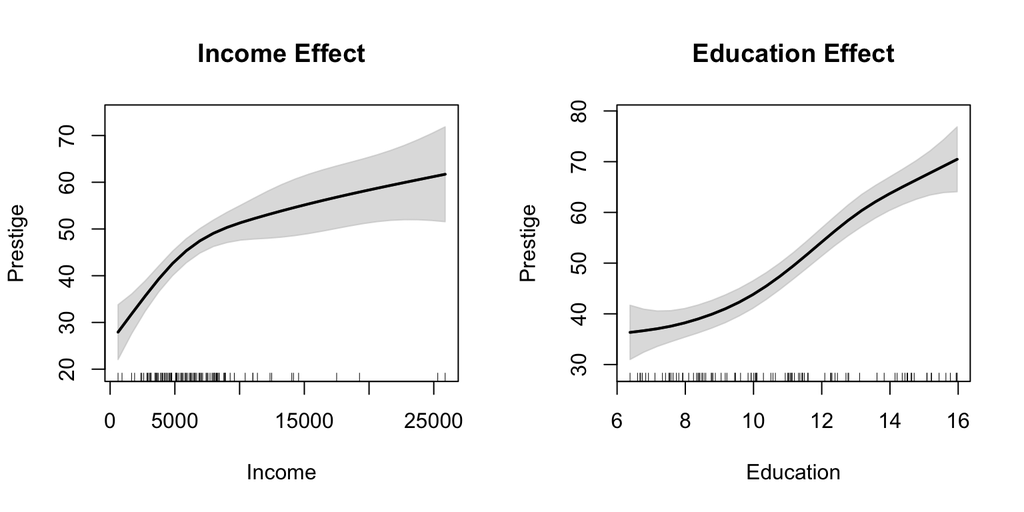

```r
# setup 1 x 2 subplots
par(mfrow = c(1,2))

# get predictor sequences
xrng <- list(income = range(Prestige$income),
             education = range(Prestige$education))
inc.seq <- seq(xrng$income[1], xrng$income[2], length.out = 25)
edu.seq <- seq(xrng$education[1], xrng$education[2], length.out = 25)

# main effect of income
newdata <- data.frame(income = inc.seq, education = mean(Prestige$education))
yhat.inc <- predict(add.gam, newdata = newdata, se.fit = TRUE)
plotci(inc.seq, yhat.inc$fit, yhat.inc$se.fit,
       xlab = "Income", ylab = "Prestige",
       main = "Income Effect")
rug(Prestige$income)

# main effect of education
newdata <- data.frame(income = mean(Prestige$income), education = edu.seq)
yhat.edu <- predict(add.gam, newdata = newdata, se.fit = TRUE)
plotci(edu.seq, yhat.edu$fit, yhat.edu$se.fit,
       xlab = "Education", ylab = "Prestige",
       main = "Education Effect")
rug(Prestige$education)
```

Plot results for interaction model:

```r
# setup 2 x 2 subplots
par(mfrow = c(2,2))

# quantiles of education
labs <- c("Low", "Low-Med", "Med-High", "High")
probs <- seq(0.2, 0.8, by = 0.2)
qvals <- unname(quantile(Prestige$education, probs = probs))
qvals
```

```
## [1]  8.128  9.708 11.172 13.620
```

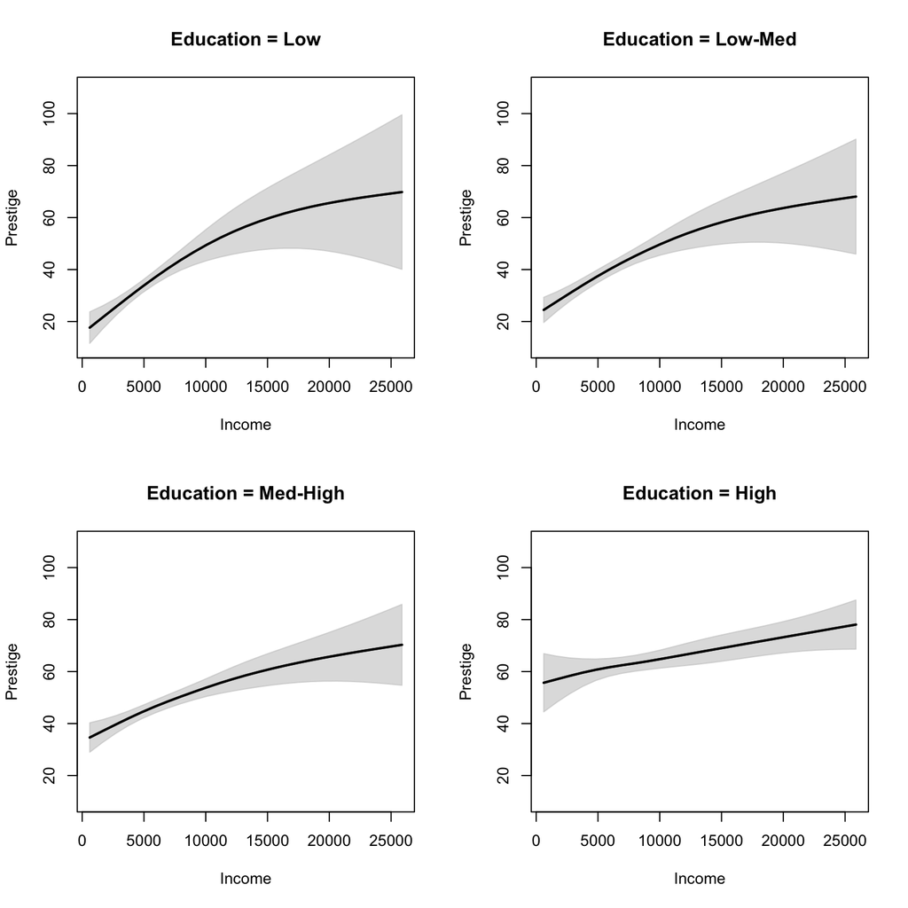

```r
# plot prestige ~ income at different education levels
for(j in 1:4){
  newdata <- data.frame(income = inc.seq, education = qvals[j])
  yhat <- predict(int.gam, newdata, se.fit = TRUE)
  plotci(inc.seq, yhat$fit, yhat$se.fit, ylim = c(10, 110),
         xlab = "Income", ylab = "Prestige",
         main = paste0("Education = ", labs[j]))
}
```

Surface plots for additive and interaction models:

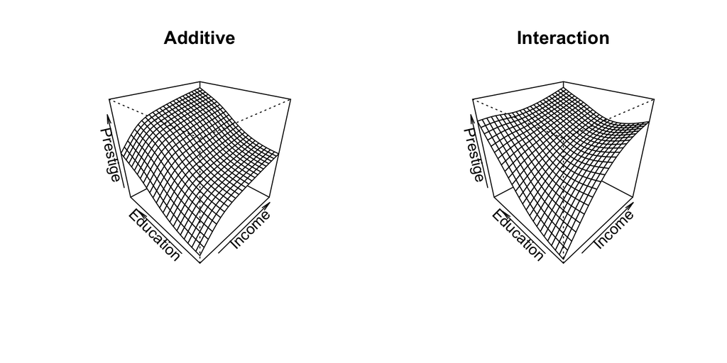

```r
# get predictions (for visualization)
inc.seq <- seq(xrng$income[1], xrng$income[2], length.out = 25)
edu.seq <- seq(xrng$education[1], xrng$education[2], length.out = 25)
newdata <- expand.grid(income = inc.seq, education = edu.seq)
yhat.add <- predict(add.gam, newdata)
yhat.int <- predict(int.gam, newdata)

# plot results
library(lattice)
par(mfrow = c(1,2))
persp(x = inc.seq, y = edu.seq, z = matrix(yhat.add, 25, 25),
      theta = -45, phi = 30, xlab = "Income", ylab = "Education",
      zlab = "Prestige", main = "Additive", zlim = c(10, 90))
persp(x = inc.seq, y = edu.seq, z = matrix(yhat.int, 25, 25),
      theta = -45, phi = 30, xlab = "Income", ylab = "Education",
      zlab = "Prestige", main = "Interaction", zlim = c(10, 90))
```

## 3.3 Analyses and Results: gsm Function

### 3.3.1 Model Fitting

R code to fit additive and interaction models with `gsm` function (using all $n = 102$ data points as knots):

```r
# additive model (using all knots)
add.gsm <- gsm(prestige ~ income + education, data = Prestige, knots = 102)
add.gsm
```

```
##
## Call:
## gsm(formula = prestige ~ income + education, data = Prestige,
##     knots = 102)
##
## Smoothing Parameter:  spar = 1   lambda = 0.9999995
## Equivalent Degrees of Freedom (Df):  7.531583
## Penalized Criterion (deviance):  4565.108
## Generalized Cross-Validation (GCV):  52.17687
```

```r
# interaction model (using all knots)
int.gsm <- gsm(prestige ~ income * education, data = Prestige, knots = 102)
int.gsm
```

```
##
## Call:
## gsm(formula = prestige ~ income * education, data = Prestige,
##     knots = 102)
##
## Smoothing Parameter:  spar = 0.9631004   lambda = 0.5412656
## Equivalent Degrees of Freedom (Df):  8.221874
## Penalized Criterion (deviance):  4377.092
## Generalized Cross-Validation (GCV):  50.76715
```

### 3.3.2 Model Summary

R code to summarize the fit models:

```r
# summarize additive model
summary(add.gsm)
```

```
##
## Call:
## gsm(formula = prestige ~ income + education, data = Prestige,
##     knots = 102)
##
## Residuals:
##      Min       1Q   Median       3Q      Max
## -15.2811  -4.6473   0.8965   3.7966  18.2977
##
## Approx. Signif. of Parametric Effects:
##             Estimate Std. Error t value  Pr(>|t|)
## (Intercept)    55.25      1.731  31.928 0.000e+00 ***
## income         33.86      6.003   5.640 1.761e-07 ***
## education      33.82      4.386   7.711 1.251e-11 ***
## ---
## Signif. codes:  0 '***' 0.001 '**' 0.01 '*' 0.05 '.' 0.1 ' ' 1
##
## Approx. Signif. of Nonparametric Effects:
##                  Df Sum Sq Mean Sq F value    Pr(>F)
## s(income)     2.299  894.7  389.16   8.053 0.0003152 ***
## s(education)  2.452  361.5  147.46   3.052 0.0418193   *
## Residuals    94.468 4565.1   48.32
## ---
## Signif. codes:  0 '***' 0.001 '**' 0.01 '*' 0.05 '.' 0.1 ' ' 1
##
## Dispersion Parameter: 48.32,   Deviance Explained: 0.8473
##   Multiple R-squared: 0.8474,   Adjusted R-squared: 0.8367
```

```r
# summarize interaction model
summary(int.gsm)
```

```
##
## Call:
## gsm(formula = prestige ~ income * education, data = Prestige,
##     knots = 102)
##
## Residuals:
##      Min       1Q   Median       3Q      Max
## -14.8121  -4.5071   0.9162   4.2439  19.3760
##
## Approx. Signif. of Parametric Effects:
##                  Estimate Std. Error t value  Pr(>|t|)
## (Intercept)         61.19      2.575  23.766 0.000e+00 ***
## income              39.41      8.200   4.807 5.825e-06 ***
## education           24.12      8.553   2.820 5.854e-03  **
## income:education   -62.59     28.195  -2.220 2.883e-02   *
## ---
## Signif. codes:  0 '***' 0.001 '**' 0.01 '*' 0.05 '.' 0.1 ' ' 1
##
## Approx. Signif. of Nonparametric Effects:
##                          Df  Sum Sq Mean Sq F value   Pr(>F)
## s(income)            0.8165   45.74   56.02   1.200 0.276093
## s(education)         2.3423  621.39  265.29   5.684 0.002963 **
## s(income:education)  3.9008  352.39   90.34   1.935 0.112619
## Residuals           93.7781 4377.09   46.67
## ---
## Signif. codes:  0 '***' 0.001 '**' 0.01 '*' 0.05 '.' 0.1 ' ' 1
##
## Dispersion Parameter: 46.67,   Deviance Explained: 0.8536
##   Multiple R-squared: 0.8537,   Adjusted R-squared: 0.8423
```

### 3.3.3 Model Comparison

Compare additive and interaction models:

```r
# pseudo F test of interaction effect
sse.dif <- add.gsm$deviance - int.gsm$deviance
df.dif <- int.gsm$df - add.gsm$df
Fstat <- (sse.dif / df.dif) / int.gsm$dispersion
pvalue <- 1 - pf(Fstat, df1 = df.dif, df2 = nrow(Prestige) - int.gsm$df)
c(Fstat, pvalue)
```

```
## [1] 5.83550252 0.02811468
```

### 3.3.4 Plot Results

Plot results for additive model:

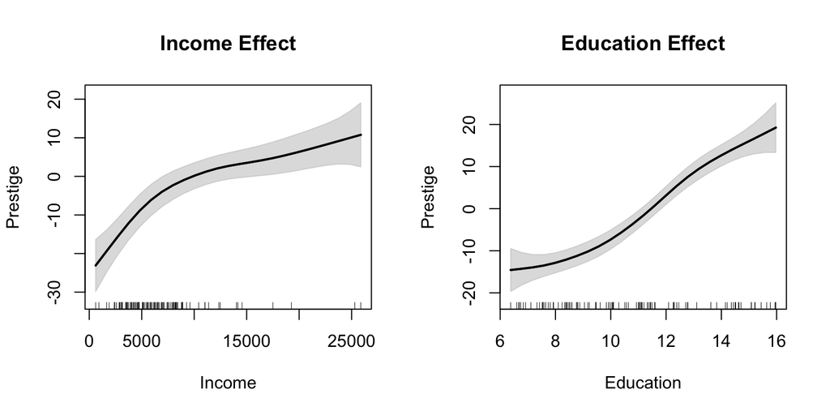

```r
# setup 1 x 2 subplots
par(mfrow = c(1,2))

# get predictor sequences
xrng <- add.gsm$specs$xrng
inc.seq <- seq(xrng$income[1], xrng$income[2], length.out = 25)
edu.seq <- seq(xrng$education[1], xrng$education[2], length.out = 25)

# main effect of income
yhat.inc <- predict(add.gsm, newdata = data.frame(income = inc.seq),
                    se.fit = TRUE, terms = "income")
plotci(inc.seq, yhat.inc$fit, yhat.inc$se.fit,
       xlab = "Income", ylab = "Prestige",
       main = "Income Effect")
rug(Prestige$income)

# main effect of education
yhat.edu <- predict(add.gsm, newdata = data.frame(education = edu.seq),
                    se.fit = TRUE, terms = "education")
plotci(edu.seq, yhat.edu$fit, yhat.edu$se.fit,
       xlab = "Education", ylab = "Prestige",
       main = "Education Effect")
rug(Prestige$education)
```

Plot results for interaction model:

```r
# setup 2 x 2 subplots
par(mfrow = c(2,2))

# quantiles of education
labs <- c("Low", "Low-Med", "Med-High", "High")
probs <- seq(0.2, 0.8, by = 0.2)
qvals <- unname(quantile(Prestige$education, probs = probs))
qvals
```

```
## [1]  8.128  9.708 11.172 13.620
```

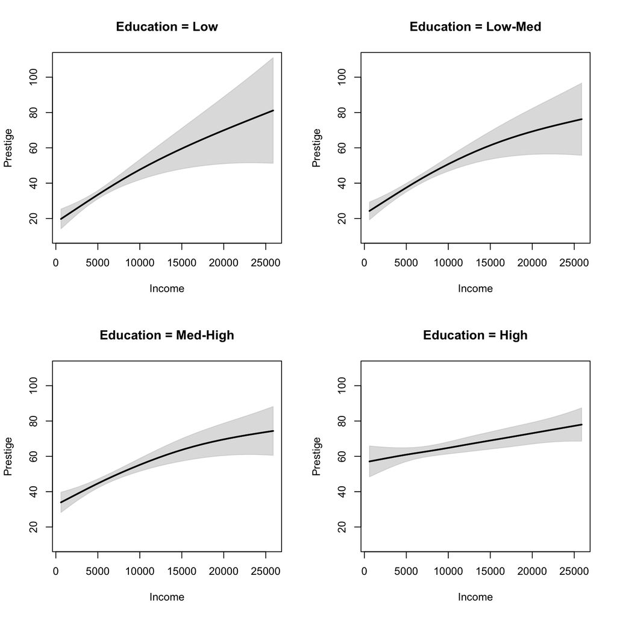

```r
# plot prestige ~ income at different education levels
for(j in 1:4){
  newdata <- data.frame(income = inc.seq, education = qvals[j])
  yhat <- predict(int.gsm, newdata, se.fit = TRUE)
  plotci(inc.seq, yhat$fit, yhat$se.fit, ylim = c(10, 110),
         xlab = "Income", ylab = "Prestige",
         main = paste0("Education = ", labs[j]))
}
```

Surface plots for additive and interaction models:

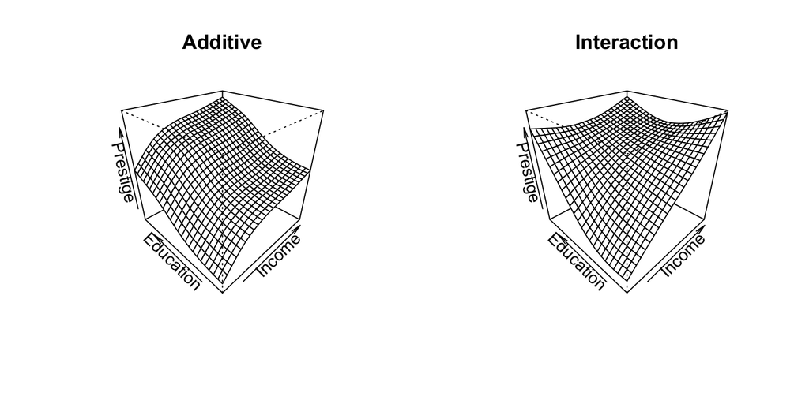

```r
# get predictions (for visualization)
xrng <- add.gsm$specs$xrng
inc.seq <- seq(xrng$income[1], xrng$income[2], length.out = 25)
edu.seq <- seq(xrng$education[1], xrng$education[2], length.out = 25)
newdata <- expand.grid(income = inc.seq, education = edu.seq)
yhat.add <- predict(add.gsm, newdata)
yhat.int <- predict(int.gsm, newdata)

# plot results
library(lattice)
par(mfrow = c(1,2))
persp(x = inc.seq, y = edu.seq, z = matrix(yhat.add, 25, 25),
      theta = -45, phi = 30, xlab = "Income", ylab = "Education",
      zlab = "Prestige", main = "Additive", zlim = c(10, 90))
persp(x = inc.seq, y = edu.seq, z = matrix(yhat.int, 25, 25),
      theta = -45, phi = 30, xlab = "Income", ylab = "Education",
      zlab = "Prestige", main = "Interaction", zlim = c(10, 90))
```

## 3.4 Analyses and Results: sm Function

### 3.4.1 Model Fitting

R code to fit additive and interaction models with `sm` function (using all $n = 102$ data points as knots):

```r
# additive model (using all knots)
add.sm <- sm(prestige ~ income + education, data = Prestige, knots = 102)
add.sm
```

```
##
## Call:
## sm(formula = prestige ~ income + education, data = Prestige,
##     knots = 102)
##
## Smoothing Parameter:  spar = 1.007553   lambda = 1.133891
## Equivalent Degrees of Freedom (Df):  7.329865
## Penalized Criterion (RSS):  4583.735
## Generalized Cross-Validation (GCV):  52.16674
```

```r
# interaction model (using all knots)
int.sm <- sm(prestige ~ income * education, data = Prestige, knots = 102)
int.sm
```

```
##
## Call:
## sm(formula = prestige ~ income * education, data = Prestige,
##     knots = 102)
##
## Smoothing Parameter:  spar = 0.9631003   lambda = 0.541265
## Equivalent Degrees of Freedom (Df):  8.221877
## Penalized Criterion (RSS):  4377.092
## Generalized Cross-Validation (GCV):  50.76715
```

### 3.4.2 Model Summary

R code to summarize the fit models:

```r
# summarize additive model
summary(add.sm)
```

```
##
## Call:
## sm(formula = prestige ~ income + education, data = Prestige,
##     knots = 102)
##
## Residuals:
##      Min       1Q   Median       3Q      Max
## -15.2685  -4.5381   0.9389   3.8369  18.2640
##
## Approx. Signif. of Parametric Effects:
##             Estimate Std. Error t value  Pr(>|t|)
## (Intercept)    55.30      1.714  32.262 0.000e+00 ***
## income         33.67      5.965   5.645 1.719e-07 ***
## education      33.95      4.322   7.856 6.172e-12 ***
## ---
## Signif. codes:  0 '***' 0.001 '**' 0.01 '*' 0.05 '.' 0.1 ' ' 1
##
## Approx. Signif. of Nonparametric Effects:
##                  Df Sum Sq Mean Sq F value    Pr(>F)
## s(income)     2.191  880.0  401.62   8.295 0.0003157 ***
## s(education)  2.338  348.3  148.96   3.076 0.0430021   *
## Residuals    94.670 4583.7   48.42
## ---
## Signif. codes:  0 '***' 0.001 '**' 0.01 '*' 0.05 '.' 0.1 ' ' 1
##
## Residual standard error: 6.958 on 94.7 degrees of freedom
## Multiple R-squared:  0.8467,    Adjusted R-squared:  0.8364
## F-statistic: 81.85 on 6.33 and 94.67 DF,  p-value: <2e-16
```

```r
# summarize interaction model
summary(int.sm)
```

```
##
## Call:
## sm(formula = prestige ~ income * education, data = Prestige,
##     knots = 102)
##
## Residuals:
##      Min       1Q   Median       3Q      Max
## -14.8121  -4.5071   0.9162   4.2439  19.3760
##
## Approx. Signif. of Parametric Effects:
##                  Estimate Std. Error t value  Pr(>|t|)
## (Intercept)         61.19      2.575  23.766 0.000e+00 ***
## income              39.41      8.200   4.807 5.825e-06 ***
## education           24.12      8.553   2.820 5.854e-03  **
## income:education   -62.59     28.195  -2.220 2.883e-02   *
## ---
## Signif. codes:  0 '***' 0.001 '**' 0.01 '*' 0.05 '.' 0.1 ' ' 1
##
## Approx. Signif. of Nonparametric Effects:
##                          Df  Sum Sq Mean Sq F value   Pr(>F)
## s(income)            0.8165   45.74   56.02   1.200 0.276093
## s(education)         2.3423  621.39  265.29   5.684 0.002963 **
## s(income:education)  3.9008  352.39   90.34   1.935 0.112620
## Residuals           93.7781 4377.09   46.67
## ---
## Signif. codes:  0 '***' 0.001 '**' 0.01 '*' 0.05 '.' 0.1 ' ' 1
##
## Residual standard error: 6.832 on 93.8 degrees of freedom
## Multiple R-squared:  0.8537,    Adjusted R-squared:  0.8423
## F-statistic: 74.98 on 7.222 and 93.78 DF,  p-value: <2e-16
```

### 3.4.3 Model Comparison

Compare additive and interaction models:

```r
# pseudo F test of interaction effect
sse.dif <- add.sm$sse - int.sm$sse
df.dif <- int.sm$df - add.sm$df
Fstat <- (sse.dif / df.dif) / int.sm$sigma^2
pvalue <- 1 - pf(Fstat, df1 = df.dif, df2 = nrow(Prestige) - int.sm$df)
c(Fstat, pvalue)
```

```
## [1] 4.96324831 0.03209404
```

### 3.4.4 Plot Results

Plot results for additive model:

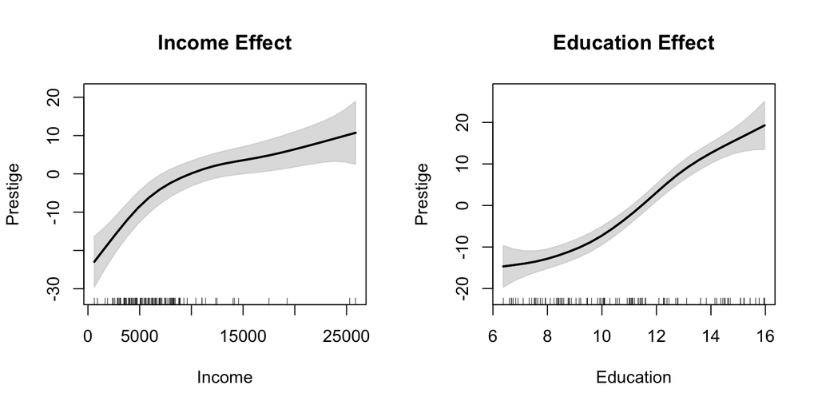

```r
# setup 1 x 2 subplots
par(mfrow = c(1,2))

# get predictor sequences
xrng <- add.sm$specs$xrng
inc.seq <- seq(xrng$income[1], xrng$income[2], length.out = 25)
edu.seq <- seq(xrng$education[1], xrng$education[2], length.out = 25)

# main effect of income
yhat.inc <- predict(add.sm, newdata = data.frame(income = inc.seq),
                    se.fit = TRUE, terms = "income")
plotci(inc.seq, yhat.inc$fit, yhat.inc$se.fit,
       xlab = "Income", ylab = "Prestige",
       main = "Income Effect")
rug(Prestige$income)

# main effect of education
yhat.edu <- predict(add.sm, newdata = data.frame(education = edu.seq),
                    se.fit = TRUE, terms = "education")
plotci(edu.seq, yhat.edu$fit, yhat.edu$se.fit,
       xlab = "Education", ylab = "Prestige",
       main = "Education Effect")
rug(Prestige$education)
```

Plot results for interaction model:

```r
# setup 2 x 2 subplots
par(mfrow = c(2,2))

# quantiles of education
labs <- c("Low", "Low-Med", "Med-High", "High")
probs <- seq(0.2, 0.8, by = 0.2)
qvals <- unname(quantile(Prestige$education, probs = probs))
qvals
```

```
## [1]  8.128  9.708 11.172 13.620
```

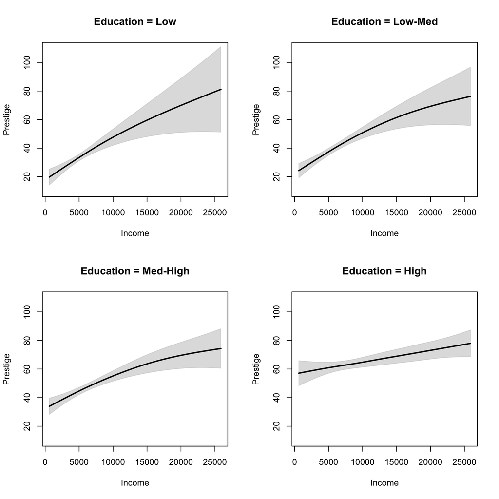

```r
# plot prestige ~ income at different education levels
for(j in 1:4){
  newdata <- data.frame(income = inc.seq, education = qvals[j])
  yhat <- predict(int.sm, newdata, se.fit = TRUE)
  plotci(inc.seq, yhat$fit, yhat$se.fit, ylim = c(10, 110),
         xlab = "Income", ylab = "Prestige",
         main = paste0("Education = ", labs[j]))
}
```

Surface plots for additive and interaction models:

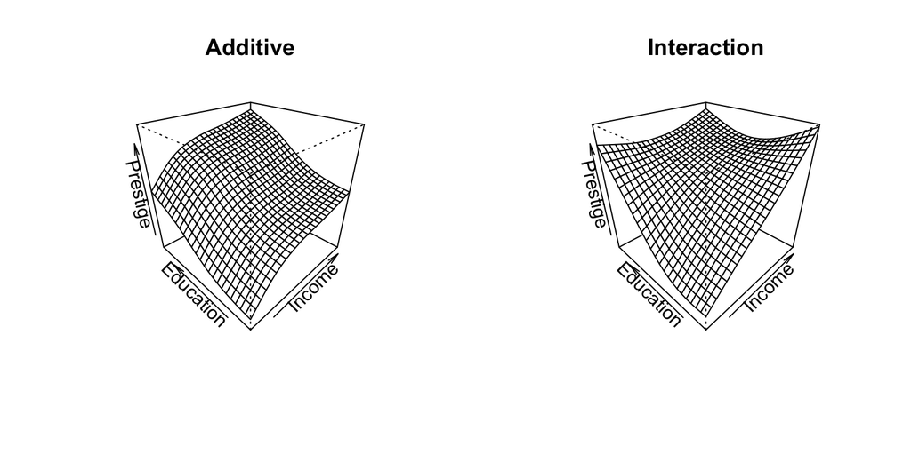

```r
# get predictions (for visualization)
xrng <- add.sm$specs$xrng
inc.seq <- seq(xrng$income[1], xrng$income[2], length.out = 25)
edu.seq <- seq(xrng$education[1], xrng$education[2], length.out = 25)
newdata <- expand.grid(income = inc.seq, education = edu.seq)
yhat.add <- predict(add.sm, newdata)
yhat.int <- predict(int.sm, newdata)

# plot results
library(lattice)
par(mfrow = c(1,2))
persp(x = inc.seq, y = edu.seq, z = matrix(yhat.add, 25, 25),
      theta = -45, phi = 30, xlab = "Income", ylab = "Education",
      zlab = "Prestige", main = "Additive", zlim = c(10, 90))
persp(x = inc.seq, y = edu.seq, z = matrix(yhat.int, 25, 25),
      theta = -45, phi = 30, xlab = "Income", ylab = "Education",
      zlab = "Prestige", main = "Interaction", zlim = c(10, 90))
```

# 4 Example 2: Titantic Survival by Age and Sex (Binomial)

## 4.1 Overview of Data

The `TitanicSurvival` dataset (from the **car** package) contains survival and demographic information for $n = 1309$ passengers on the Titanic. We will use a nonparametric logistic regression model to model the probability of survial as a function of age and sex.

First, let’s load the data and visualize the relationship between age ($X_1$), sex ($X_2$), and survival ($Y$).

```r
# load data
library(car)
data(TitanicSurvival)
head(TitanicSurvival)
```

```
##                                 survived    sex     age passengerClass
## Allen, Miss. Elisabeth Walton        yes female 29.0000            1st
## Allison, Master. Hudson Trevor       yes   male  0.9167            1st
## Allison, Miss. Helen Loraine          no female  2.0000            1st
## Allison, Mr. Hudson Joshua Crei       no   male 30.0000            1st
## Allison, Mrs. Hudson J C (Bessi       no female 25.0000            1st
## Anderson, Mr. Harry                  yes   male 48.0000            1st
```

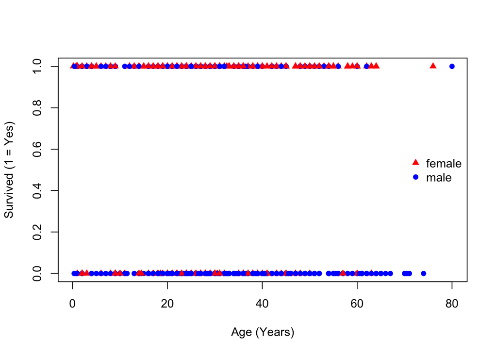

```r
# plot survived ~ age * sex
y <- ifelse(TitanicSurvival$survived == "yes", 1, 0)
plot(TitanicSurvival$age, y,
     xlab = "Age (Years)", ylab = "Survived (1 = Yes)",
     pch = ifelse(TitanicSurvival$sex == "male", 16, 17),
     col = ifelse(TitanicSurvival$sex == "male", "blue", "red"))
legend("right", c("female", "male"), pch = c(17, 16),
       col = c("red", "blue"), bty = "n")
```

## 4.2 Analyses and Results: gam Function

### 4.2.1 Model Fitting

R code to fit additive and interaction models with `gam` function:

```r
# additive model
add.gam <- gam(y ~ sex + s(age, bs = "cr"),
               family = binomial, data = TitanicSurvival)
add.gam
```

```
##
## Family: binomial
## Link function: logit
##
## Formula:
## y ~ sex + s(age, bs = "cr")
##
## Estimated degrees of freedom:
## 6.91  total = 8.91
##
## UBRE score: 0.04974017
```

```r
# interaction model
int.gam <- gam(y ~ sex + s(age, bs = "cr", by = sex),
               family = binomial, data = TitanicSurvival)
int.gam
```

```
##
## Family: binomial
## Link function: logit
##
## Formula:
## y ~ sex + s(age, bs = "cr", by = sex)
##
## Estimated degrees of freedom:
## 1.00 6.98  total = 9.98
##
## UBRE score: 0.02615761
```

### 4.2.2 Model Summary

R code to summarize the fit models:

```r
# summarize additive model
summary(add.gam)
```

```
##
## Family: binomial
## Link function: logit
##
## Formula:
## y ~ sex + s(age, bs = "cr")
##
## Parametric coefficients:
##             Estimate Std. Error z value Pr(>|z|)
## (Intercept)   1.1228     0.1191   9.425   <2e-16 ***
## sexmale      -2.4907     0.1549 -16.075   <2e-16 ***
## ---
## Signif. codes:  0 '***' 0.001 '**' 0.01 '*' 0.05 '.' 0.1 ' ' 1
##
## Approximate significance of smooth terms:
##          edf Ref.df Chi.sq p-value
## s(age) 6.911  7.976  18.38   0.016 *
## ---
## Signif. codes:  0 '***' 0.001 '**' 0.01 '*' 0.05 '.' 0.1 ' ' 1
##
## R-sq.(adj) =  0.302   Deviance explained = 23.6%
## UBRE = 0.04974  Scale est. = 1         n = 1046
```

```r
# summarize interaction model
summary(int.gam)
```

```
##
## Family: binomial
## Link function: logit
##
## Formula:
## y ~ sex + s(age, bs = "cr", by = sex)
##
## Parametric coefficients:
##             Estimate Std. Error z value Pr(>|z|)
## (Intercept)   1.1662     0.1226   9.515   <2e-16 ***
## sexmale      -2.5622     0.1590 -16.112   <2e-16 ***
## ---
## Signif. codes:  0 '***' 0.001 '**' 0.01 '*' 0.05 '.' 0.1 ' ' 1
##
## Approximate significance of smooth terms:
##                    edf Ref.df Chi.sq  p-value
## s(age):sexfemale 1.000  1.001  6.958  0.00835 **
## s(age):sexmale   6.979  8.030 36.329 8.79e-06 ***
## ---
## Signif. codes:  0 '***' 0.001 '**' 0.01 '*' 0.05 '.' 0.1 ' ' 1
##
## R-sq.(adj) =   0.32   Deviance explained = 25.5%
## UBRE = 0.026158  Scale est. = 1         n = 1046
```

### 4.2.3 Model Comparison

Compare additive and interaction models:

```r
# pseudo Chisq test of interaction effect
sse.dif <- add.gam$deviance - int.gam$deviance
df.dif <- sum(int.gam$edf1) - sum(add.gam$edf1)
pvalue <- 1 - pchisq(sse.dif, df = df.dif)
c(sse.dif, pvalue)
```

```
## [1] 2.680526e+01 2.547716e-07
```

```r
# analysis of deviance table (gam)
anova(add.gam, int.gam, test = "Chisq")
```

```
## Analysis of Deviance Table
##
## Model 1: y ~ sex + s(age, bs = "cr")
## Model 2: y ~ sex + s(age, bs = "cr", by = sex)
##   Resid. Df Resid. Dev     Df Deviance  Pr(>Chi)
## 1      1036     1080.2
## 2      1035     1053.4 1.0544   26.805 2.548e-07 ***
## ---
## Signif. codes:  0 '***' 0.001 '**' 0.01 '*' 0.05 '.' 0.1 ' ' 1
```

### 4.2.4 Plot Results

Plot results for additive and interaction models:

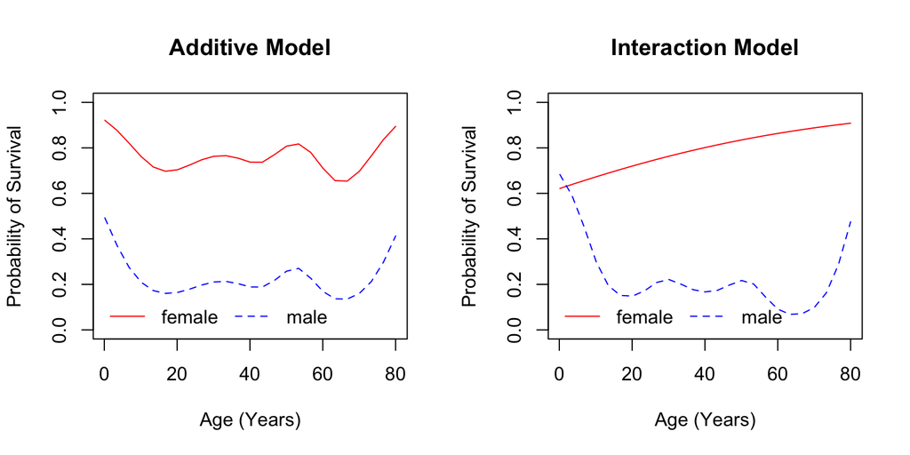

```r
# get predictions (for visualization)
xrng <- list(age = range(TitanicSurvival$age, na.rm = TRUE))
age.seq <- seq(xrng$age[1], xrng$age[2], length.out = 25)
sex.seq <- c("female", "male")
newdata <- expand.grid(age = age.seq, sex = sex.seq)
yhat.add <- predict(add.gam, newdata, type = "response")
yhat.int <- predict(int.gam, newdata, type = "response")

# additive model
par(mfrow = c(1,2))
plot(age.seq, yhat.add[1:25], ylim = c(0, 1), t = "l", col = "red",
     xlab = "Age (Years)", ylab = "Probability of Survival",
     main = "Additive Model")
lines(age.seq, yhat.add[1:25 + 25], lty = 2, col = "blue")
legend("bottomleft", legend = c("female", "male"), lty = 1:2,
       col = c("red", "blue"), horiz = TRUE, bty = "n")

# interaction model
plot(age.seq, yhat.int[1:25], ylim = c(0, 1), t = "l", col = "red",
     xlab = "Age (Years)", ylab = "Probability of Survival",
     main = "Interaction Model")
lines(age.seq, yhat.int[1:25 + 25], lty = 2, col = "blue")
legend("bottomleft", legend = c("female", "male"), lty = 1:2,
       col = c("red", "blue"), horiz = TRUE, bty = "n")
```